# Tutorial 5 - Data Wrangle

Author: Matthew J. Cossley

Last update: 01 May, 2022

## Learning objectives

- Get lots of hands-on practice with `R` and `data.table` and `ggplot`.
- Do some actual real-world data wrangling.
- Use the `pattern` argument of `list.files` to select only `.csv` files.
- Use the `file.size` function to filter out empty or incomplete data files.
- Query how many unique values exist within a `data.table` column using syntax like `d[, length(unique(subject))]`.
- Begin developing an understanding of Null Hypothesis Significance Testing.
- Begin developing an understanding of when it is appropriate to apply a **t-test** and begin practising how to do so in`R`.
- Clear up lingering confusions by using this time to meaningfully interact with your tutor.

## Get some experiment data

- If you haven’t already participated in the following short demo experiment, please do so at the following address: `https://run.pavlovia.org/demos/stroop/`
- Next, go here: `https://gitlab.pavlovia.org/demos/stroop`
- Read about the experiment you just participated in by scrolling to the bottom and reading the `README.md` file.
- Click the `data` folder to land at the following address: `https://gitlab.pavlovia.org/demos/stroop/tree/master/data`
- In previous tutorials, I instructed you to find and download only your data, or else to download a small batch of hand selected data (somewhere around 5 files). Here, we will download the whole batch and deal with a few of the data wrangling challenges that come along for the ride.
- Click the download icon and then `Download zip`. This will download the entire repository to your computer. Move the `data` folder to a location that makes loading files in from `R` convenient.

## Get ready to analyse your data

- If you haven’t done so already, create a new folder on your computer named `cogs2020`
- Open Rstudio and click `File > New File > R Script`
- In Rstudio click `File > Save`
- In the prompt that comes up, name your file `tutorial_5_notes.R`, and save it in your `cogs2020` folder.
- Move the batch `.csv` files you just downloaded into your `cogs2020` folder.

## Analyse your data using `data.table` and `ggplot`

- In our previous tutorial we learned how to wrangle a folder full of separate files into one big coherent `data.table`. However, we hand selected the data files that were suitable for our needs (e.g., `csv` files from complete data sets). Here, we downloaded the entire folder, and as a consequence, we will have to filter out the files we don’t want.
- The following code chunk augments the approach we used last week to wrange everything into a single `data.table` with all of your data contained within.

```r
# Load the `data.table` and `ggplot2` libraries and `rm` to
# be sure your are starting with a clean work space.
library(data.table)
library(ggplot2)

rm(list = ls())

# Use the `list.files` function to save a list of file paths
# corresponding to your just downloaded data files. Here, I
# have written `'data/stroop'` because that is where I put
# the data that I downloaded. You will need change this to
# something appropriate to where you put these files.
file_list <- list.files('data/stroop',
                        full.names=T,
                        pattern='.csv$' # select only .csv files
                        )

# Here, we have used the `pattern` argument of the
# `list.files` function to select only the files in our data
# directory that have a `.csv` in their file name. The
# trailing `$` is saying that the `.csv` bit needs to come
# at the end of the file name. However, we will still have
# to deal with the fact that some of these csv files are
# empty.

# create an empty list with as many elements as we have data
# files
d_list <- vector("list", length(file_list))

# iterate through our list of data files and read each into
# a data.table, which we then store in d_list
for(i in 1:length(file_list)) {

  # Check the file size, and if it's too small to be actual
  # data, then skip it
  if( file.size(file_list[[i]]) > 5){

    z <- fread(file_list[[i]], )
    z[, subject := i]
    d_list[[i]] <- z

  }
}

# bind our list of data.tables into one big data.table
d <- rbindlist(d_list)

# ask how many unique subjects we have (which for us in this
# example is equivalent to the number of unique files you've
# loaded)
d[, length(unique(subject))]
```

```
## [1] 431
```

- Please consult your tutorial notes from last week if the above doesn’t seem at all familiar.
- We next move on to the visualisations using `ggplot2` following last weeks template exactly.
- The classic Stroop finding is that people are slower and less accurate on incongruent trials (i.e., trials on which stimulus text and stimulus colour do not match) than they are on congruent trials. Lets see if our data pan out that way.

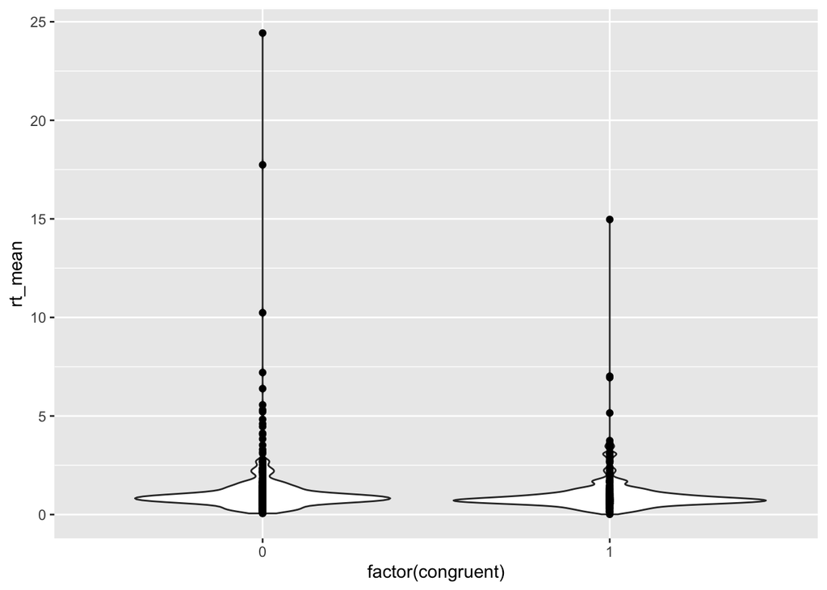

```r
# first create a column to indicate response accuracy
d[, acc := corrAns == resp.keys]

# report what your overall accuracy and rt was grouped by
# subject and grouped by congruent
dd <- d[,
        .(acc_mean = mean(acc), rt_mean = mean(resp.rt)),
        .(subject, congruent)]

# inspect reaction time
ggplot(dd, aes(x=factor(congruent), y=rt_mean)) +
  geom_violin() +
  geom_point()
```

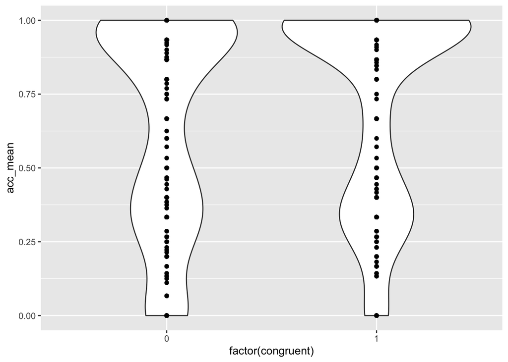

```r
# inspect accuracy
ggplot(dd, aes(x=factor(congruent), y=acc_mean)) +
  geom_violin() +
  geom_point()
```

### Single-sample t-test

- In this tutorial, we begin formalising our analysis through the use of inferential statistics (i.e., Null Hypothesis Significance Testing – NHST). The fundamental logic of NHST is a cornerstone of this unit that we will spend considerable lecture and problem set time developing and practising. Here, we will begin developing skill in recognising when to apply one type of test or another. We will also begin developing the practical ability to use `R` to perform these tests.
- The first step of any hypothesis testing system is to ask a simple and explicit question about the source of your data. E.g.:
  - **Is the true reaction time across all trials – not distinguishing between congruent or incongruent – less than 3 seconds?**
- The next critical step is to understand how your observations are likely distributed. That is, what random variable did they come from? A good first step to answer this question is to ask whether your data is continuous or discrete. If it is continuous, then a common assumption is that the data came from a random variable with a Normal distribution. That seems to be a good bet for both of our current observation columns (`acc_mean` and `rt_mean`).
- The next step of NHST is to reframe your core question in terms of the parameters of the random variable that you decided on just above. Here, this means that we assume that $X$ is the random variable that generates reaction times on every trial of this Stroop experiment. The question of whether or not reaction times are greater that 3 seconds is then equivalent to asking if the population mean of $X$ is less than 3 or not.
- **If your observations come from a random variable or random variables with Normal distributions and you are interested in the population mean of these random variables, then it is appropriate to use a t-test.**
- `R` makes this very easy for you with the function `t.test`

```r
x <- dd[, rt_mean]
t.test(x,
       alternative='less', # we are testing if x < 3
       mu=3, # the population mean we are asking about
       )
```

```
##
##  One Sample t-test
##
## data:  x
## t = -38.831, df = 835, p-value < 2.2e-16
## alternative hypothesis: true mean is less than 3
## 95 percent confidence interval:
##      -Inf 1.185264
## sample estimates:
## mean of x
##    1.1049
```

- The output of this function is a lot. It will all be explained in this weeks lecture.
- For now, you should at least notice the output that reads **p-value**. We will have lots to say about this, but as you likely already know, if the p-value is less than 0.05, then we believe that the population mean of $X$ really is less than 3.

### Two-sample t-test

- Suppose our question was something more like the following:
  - **Is the true reaction time on congruent trials less than it is on incongruent trials?**
- Here, we assume that $X$ is a random variable that generates reaction times on congruent trials and $Y$ is a random variable that generates reaction times on incongruent trials. The question of whether or not congruent trials are easier than incongruent trials is now equivalent to asking if the population mean of $X$ is smaller than the population mean of $Y$.
- Since we are again dealing with continuous data that we are assuming is Normally distributed and our question is about population means, a t-test is again a reasonable thing to do. In this case, since we are comparing two means, we use a two-sample t-test.
- However, since each participant provides a measurement of both congruent and incongruent reaction times, we have a repeated measures design, and this will turn out to require us to perform a paired samples t-test. Again, `R` makes this type of `t.test` very easy to implement.

```r
# exclude participants that do not have measurements for
# both congruent and incongruent trial types.
dd[, n_congruent := length(unique(congruent)), .(subject)]
ddd <- dd[n_congruent == 2]

t.test(rt_mean ~ congruent,
       data=ddd,
       alternative='greater',
       mu=0, # by default we assume that x=y and therefore there is *zero* difference
       paired=T # tell R we have repeated measures
       )
```

```
##
##  Paired t-test
##
## data:  rt_mean by congruent
## t = 2.0247, df = 404, p-value = 0.02178
## alternative hypothesis: true difference in means is greater than 0
## 95 percent confidence interval:
##  0.03167551        Inf
## sample estimates:
## mean of the differences
##               0.1705534
```

## Work on problem set 5

- Problem set 5